A field report from an artificial economy

# Bitcoin vs. the *Printing Press*

Five questions about money and the average household, put to an economy where fiat, bitcoin and a dual-currency hybrid can all be run side by side.

“Bitcoin”: a fixed money supply “Fiat”: central-bank money that grows “Hybrid”: fiat and bitcoin side by side

Based on Barry Becker’s agent-based simulator · experiments and write-up by an AI analyst · October 2026

## A small economy you can rerun at will

Barry Becker is a retired software engineer and the author of the novel [*Into the Singularity*](https://www.amazon.com/dp/B0HLW7GZF6). He built an **agent-based economy simulator**: thousands of simulated households, hundreds of firms, a handful of banks, a government and (under fiat) a central bank. Month by month for twenty simulated years, they work, shop, borrow, save, renegotiate wages and sometimes go bust. Nobody tells the economy what to do. Booms, slumps, inflation and deflation all emerge from millions of small decisions.

That makes it a laboratory for a question usually argued in slogans: **would ordinary people be better off with bitcoin-like money that can’t be printed, or with ordinary government money?** This report asks it five ways. Each case has a button that opens the live app with the same settings, so you can rerun it yourself.

> “The simulation cannot show that one monetary system is better in the real world. It shows which assumptions a conclusion depends on.”

### How to read the charts

Each line is the month-by-month **median of 6 simulated histories** (random seeds 1–6), lightly smoothed. “Typical household’s real consumption” is the median household’s consumption in goods, not dollars or sats, so fiat and bitcoin can be compared directly.

### Two kinds of number

- Runs numbers come from 6 runs of each setting: 4,000 households, 200 firms and 4 banks over 240 months (20 years). “Average” means years 2–20. For paired comparisons we say how many of the 6 runs agree.
- Live app buttons open the deployed app with exactly those settings. Press **Run** to reproduce the charts.

**One setting held fixed throughout:** AI adoption is set to **None**, so the results are about money, not robots. Prices and output respond to demand, households open with today’s mix of renters, owners and mortgages, and random shocks hit about once a decade unless a case says otherwise.

01

Case one · The baseline

## Same economy, two kinds of money

Run one economy twice: once with central-bank money, once with a fixed supply. Under fiat, prices rise about **2% a year** (×1.49 over 20 years). Under bitcoin they fall about **1% a year** (×0.84). Bitcoin costs some jobs, but the typical household’s living standard ends up close to fiat’s.

5.1%vs6.4%

Average unemployment, fiat vs bitcoin. Bitcoin is higher in all 6 paired runs (+1.3 points).

Runs

+1.8%

Typical real consumption under bitcoin vs fiat, years 2–20 (higher in 4 of 6 runs). Year 20: −1.3%.

Runs

64%vs65%

Share of household wealth held by the richest fifth in year 20, fiat vs bitcoin

Runs

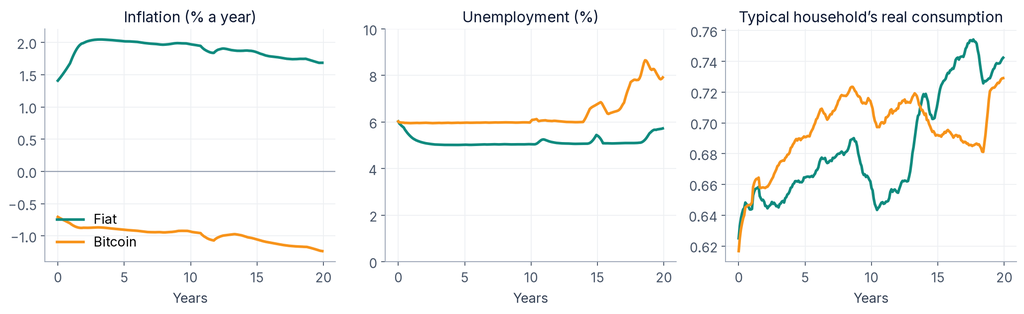

Runs**How to read:** teal = fiat, orange = bitcoin, medians of 6 runs. Left: steady inflation vs mild deflation. Middle: bitcoin unemployment sits about a point above fiat’s. Right: typical consumption tracks closely in both worlds.

Live app▶ Fiat baseline▶ Bitcoin baselineTo overlay the two: open the fiat link, press Run, press “Pin as baseline”, switch the Monetary regime to bitcoin and press Run again. Several runs at full size take a few minutes in a browser; set “Num seeds” to 1 for a quick look.

### What would it take to turn deflation into a slump?

We tried the behavioural assumptions that usually turn deflation into a slump: debtors **three times as sensitive** to deflation, people who **expect deflation to continue**, **very sticky wages**, and all three together. None of them moves average unemployment by more than 0.2 points (6.4–6.6%), and the worst month stays near 9%. At about 1% a year, deflation is too gentle for these levers to bite.

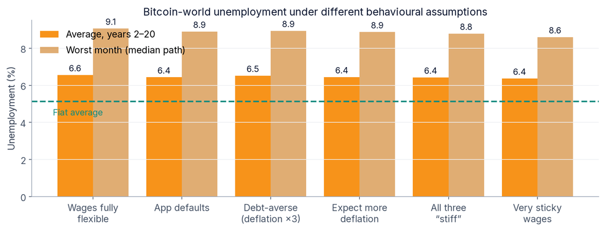

Runs**How to read:** bitcoin-world unemployment under each assumption. Dark bars: average over years 2–20. Light bars: worst month on the median path. Dashed teal: the fiat average (5.1%). The bars are nearly flat.

Live app▶ Very sticky wages▶ All three “stiff” assumptions▶ Fully flexible wages

**The slump shows up elsewhere.** Unemployment in the teens appears only when the economy is hit by repeated large shocks (Case 4).

So what

Gentle deflation costs about a point of employment and little else. The interesting differences come from debts, crises and the mix of monies.

02

Case two · Who carries the debt

## Old debts in a world of falling prices

Every run opens with households as they are today: about **40% of all households** owe a mortgage fixed in money. Inflation slowly shrinks that debt; deflation makes it heavier. Remove the inherited mortgages and bitcoin households come out ahead.

+4.6%

Typical bitcoin consumption without the inherited book, years 2–20 (higher in all 6 runs; +5.7% in year 20)

Runs

65%→58%

Richest fifth’s share of household wealth under bitcoin, with vs without the old mortgages

Runs

+61%

Typical bitcoin household’s real wealth in year 20 without the old book (49.5 vs 30.7)

Runs

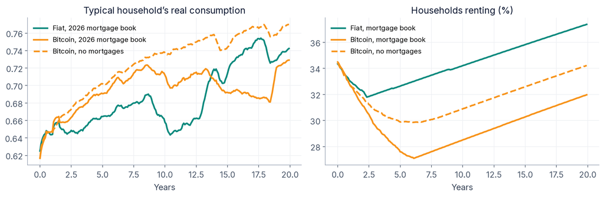

Runs**How to read:** solid = today’s mortgage book, dashed = no inherited mortgages. Left: the debt-free bitcoin household (dashed orange) runs above both others. Right: renting by year 20 is 32% under bitcoin with the book, 34% without, and 37% under fiat.

Live app▶ Bitcoin, today’s mortgage book▶ Bitcoin, no inherited mortgages▶ Fiat, today’s mortgage book

Barry’s view

Barry’s view is that a mortgage as we know it, a long loan fixed in money, doesn’t make sense under a bitcoin standard. Seen that way, the fair comparison is a bitcoin world *without* the inherited book against today’s fiat world *with* it. On that comparison the typical bitcoin household consumes **7.2% more** over years 2–20 (higher in all 6 runs) and 4.7% more in year 20. Unemployment is still 1.5 points higher.

**Caveat:** this setting removes only the *opening* mortgages. New home loans still get written (about 290 per run over 20 years). No bank fails in either setting.

So what

Debts written for a world of rising prices are bitcoin’s main handicap here. Without them, bitcoin households are better off and wealth is less concentrated.

03

Case three · How firms adjust

## Pay that barely needs to fall

Each firm’s pay drifts toward an **agreed wage** set by prices, productivity and the job market, and employers can win pay cuts as easily as workers win raises. With prices drifting down only 1% a year, bitcoin money wages hardly need to move, so the speed of renegotiation stops mattering.

+2%vs+79%

Change in the money wage over 20 years, bitcoin vs fiat. Real pay rises 22% under bitcoin, 20% under fiat.

Runs

6.6·6.4·6.4

Average bitcoin unemployment (%) with instant, default (10% of the gap a month) and very sticky (5%) pay

Runs

5.1%→5.9%

Fiat unemployment when pay resets instantly (higher in all 6 runs)

Runs

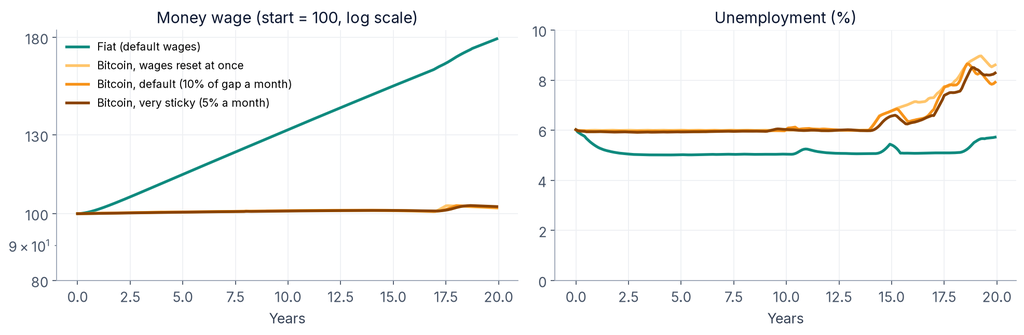

Runs**How to read:** left, the money wage (start = 100, log scale). Fiat pay climbs steadily; the three bitcoin lines stay near 100. Right, unemployment: the three bitcoin lines nearly overlap.

Live app▶ Instant renegotiation▶ Default (10% a month)▶ Very sticky (5% a month)The setting is “Nominal wage rigidity” in the Households and firms group: 0 = instant, 0.9 = default, 0.95 = very sticky.

**A twist under fiat:** instant renegotiation costs fiat 0.8 points of employment, while typical consumption is 1.3% higher. A little stickiness steadies jobs while prices rise.

So what

Wage stickiness matters when prices move a lot. Under steady, gentle deflation it barely matters at all.

04

Case four · Crises and the printing press

## When the printer runs

The fiat central bank **prints when a crisis hits**: when unemployment rises two points above its natural rate, money growth speeds up a few months later, and it can never be frozen at zero. We made the world stormy, with each boom-and-bust shock starting as the last one ends at three times the default size, and compared four rulebooks: fiat with crisis printing off, fiat with it on (the default), a full **“printing press”** (maximum crisis stimulus, a central bank buying half of new government debt, and deficit spending), and bitcoin.

9.5%vs5.8%

Average unemployment, bitcoin vs printing press (ordinary fiat: 6.8%). Worst months: 14.4% vs 9.1%.

Runs

Runs

≈0

What crisis printing alone changes in ordinary fiat: unemployment 6.7% off vs 6.8% on

Runs

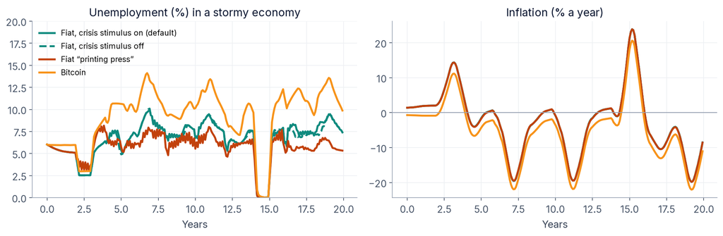

Runs**How to read:** left, unemployment. Bitcoin (orange) peaks highest in each bust; the two plain-fiat lines nearly overlap. Right, inflation. Every regime swings widely, from roughly −20% to +25% a year.

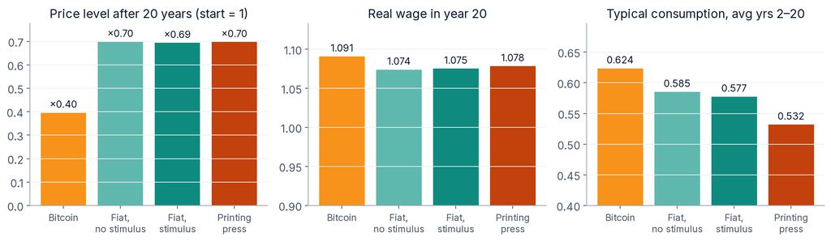

Runs**Who fares how:** left, the price level after 20 years. Repeated busts push prices down in every regime: ×0.40 under bitcoin, about ×0.70 under all three fiat rulebooks. Middle, the year-20 real wage. Right, typical consumption over years 2–20: bitcoin highest, the printing press lowest.

Live app▶ Fiat, crisis printing on▶ Fiat, crisis printing off▶ Printing press▶ Bitcoin

### How fiat and bitcoin households fare

Barry’s view

Barry doubts that politicians could ever hold money growth at zero. The pull, in a crisis or before an election, is always toward printing more. The app builds that in: fiat money growth can’t be set to zero, and crisis stimulus is on by default. He also sees helicopter money as meaningless under bitcoin, and the bitcoin regime ignores the stimulus and money-growth settings. The “printing press” here is a fixed rulebook; nothing models printing that ratchets up over time.

So what

In a stormy world, printing buys jobs and a more equal wealth split, but not consumption. Bitcoin costs the most jobs yet leaves the typical household consuming the most.

05

Case five · The hybrid question

## Two monies at once

In the **hybrid** regime, fiat and bitcoin circulate together. Goods are priced in dollars, the central bank still runs fiat policy and backstops banks, and bitcoin trades at a **given BTC/USD path** that households can’t move. Turn on **Money choice speed** and households and firms shift their holdings, and the currency they are paid in, toward the money they score higher: fiat by its **legal-tender pull**, bitcoin by **trust** plus its real return.

36→124→386

Typical household’s real wealth in year 20: fiat, hybrid with choice off, hybrid with choice on at trust 1.5

Runs

−26%

Typical hybrid consumption vs fiat, years 2–20 (lower in all 6 runs). Turning choice on lowers it another 12%, and trust 1.5 another 22%.

Runs

0

Bank failures in every hybrid run, including the stormy world (bitcoin: 5.5)

Runs

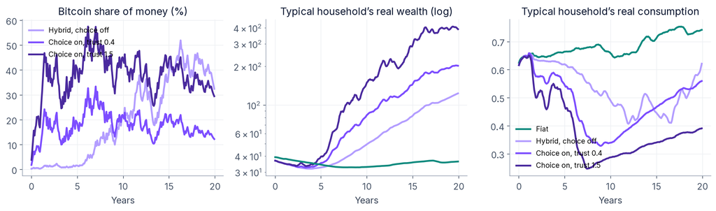

Runs**How to read:** left, bitcoin’s share of money. With choice off it climbs only as the price path rises (33% by year 20). With choice on it settles where the scores put it: 12% at the default trust of 0.4, 30% at trust 1.5. Middle, typical real wealth (log scale) soars with the bitcoin price. Right, typical consumption falls well below fiat’s, most at high trust.

Live app▶ Hybrid, choice off▶ Hybrid, choice on▶ Choice on, bitcoin trust 1.5▶ Choice on, legal-tender pull 0.5Open the “Money” chart group to see the shares.

### Who gains from trusting bitcoin

More bitcoin in the mix means more paper wealth, less consumption and a more top-heavy distribution. Unemployment stays at 6.0% throughout.

12%·18%·30%·41%

Bitcoin share in year 20: default; legal-tender pull 0.5; trust 1.5; trust 2

Runs

62%·65%·70%·68%

Richest fifth’s wealth share, same four settings (choice off: 56%; fiat: 64%)

Runs

12%·14%·16%·11%

Households at the consumption floor, average over years 2–20 (fiat: 7%)

Runs

### Switching overnight

For comparison, a one-step switch from fiat to bitcoin at month 60 raises unemployment to 5.8% (fiat: 5.1%) and leaves typical consumption 5% behind fiat over years 2–20 (lower in 4 of 6 runs).

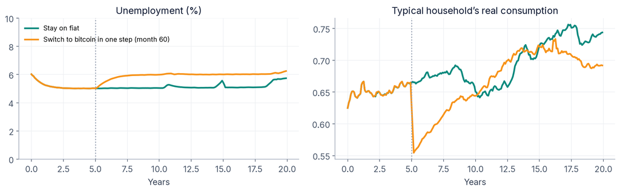

Runs**How to read:** the dotted line marks the switch at month 60. Teal = stay on fiat, orange = switch to bitcoin.

Live app▶ Overnight switch at month 60

So what

The hybrid’s safety net keeps every bank alive, and a rising bitcoin makes households far richer on paper. But in this model that wealth doesn’t turn into consumption: the typical hybrid household consumes less than under either single money, and trusting bitcoin more widens the gap.

The big picture

## The coin matters less than the plumbing around it

Across all five cases, whether fixed-supply money helps or hurts the average household depends on a few features that have little to do with the coin itself:

### 1What debts people carry

Loans written for rising prices are bitcoin’s main handicap. Without them, bitcoin households consume more than fiat ones (Case 2).

### 2How stormy the world is

Gentle deflation costs about a point of employment. Big repeated shocks are what push bitcoin unemployment into the teens (Cases 1 and 4).

### 3How hard the printer runs

Heavy printing buys jobs and a more equal wealth split, but lower consumption (Case 4).

### 4How much people trust bitcoin

In a hybrid, more trust means more paper wealth, less consumption and more concentration at the top (Case 5).

### What the current app does not do (yet)

**Bitcoin’s price is given.** In the hybrid, the BTC/USD rate follows a fixed path. Household demand for bitcoin doesn’t move it.

**One closed economy.** There is no foreign trade, and goods have a single price.

**Today’s debts in every world.** Bitcoin runs open with a 2026-style mortgage book unless a case removes it.

**Printing is a fixed rule.** Crisis stimulus responds to unemployment, but nothing models political pressure ratcheting it up over time.

**Random crises only.** Shocks can be made bigger and more frequent, but not scheduled for a particular date.

**A small sample of futures.** Each setting is 6 random histories of a 4,000-household economy. Treat small differences as noise.

**A teaching tool, not a forecast.** The simulator is a deliberately simplified economy. Treat every number here as evidence about *assumptions*, never as proof about the real world. Change an assumption in the app and watch the conclusion move. That is the point.

### Try it yourself

Every “Live app” button above opens the simulator with that case’s settings already loaded. Press Run, then “Pin as baseline”, change one setting and run again to see the two histories side by side.

[Open the economy simulator →](https://barrybecker4.org/programming-projects/economy-simulation/index.html) barrybecker4.org/programming-projects/economy-simulation